# Praca domowa 2

Imię Nazwisko - Antoni Kobosz

## Dane

Dane wykorzystane w Pracy domowej 2 dotyczą wyników egzaminów z 3 umiejętności: czytania, pisania i operacji matematycznych. Dodatkowo dostępne są podstawowe informacje o studentach i ich rodzicach. Opis wszystkich kolumn znajduje się również w pliku `README.md`.

| Zmienna | Opis |
| --- | --- |
| **gender** | płeć |
| **race.ethnicity** | pochodzenie etniczne |
| **parental.level.of.education** | wykształcenie rodziców |
| **lunch** | jaki obiad jedli uczniowie w dniu egzaminu |
| **test.preparation.course** | czy uczeń odbył kurs przygotowujący |
| **math.score** | wynik egzaminu z matematyki |
| **reading.score** | wynik egzaminu z czytania |
| **writing.score** | wynik egzaminu z pisania |

## Zadanie 1

Jak wyglądają rozkłady wyników uczniów z trzech przedmiotów (matematyka, czytanie, pisanie)?

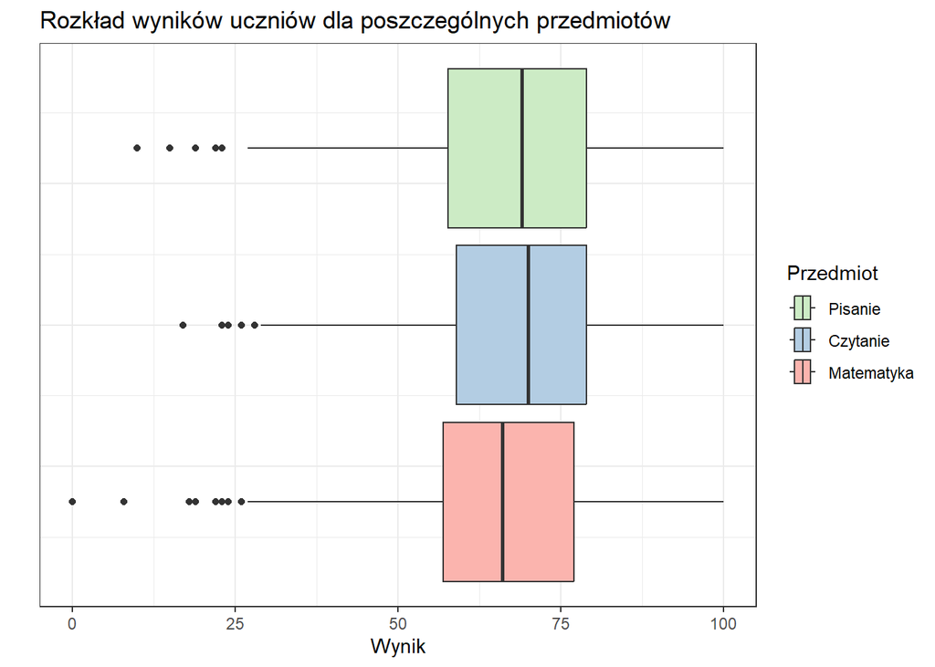

```r
# Tu umieść kod do wygenerowania odpowiedzi do zadania.
df %>% select(Matematyka=math.score,Czytanie=reading.score,Pisanie=writing.score) %>%
  pivot_longer(cols = everything(),names_to = "Kategoria",values_to = "wynik") %>%
  mutate(Kategoria = factor(Kategoria,levels = c("Matematyka","Czytanie","Pisanie"))) %>% # Ustawiam factor recznie zeby przedmioty byly wyswielone w takiej kolejnosci
  ggplot(aes(x=wynik,fill=Kategoria)) + geom_boxplot() + theme_bw() +
  labs(x="Wynik",y="",fill="Przedmiot",title = "Rozkład wyników uczniów dla poszczególnych przedmiotów") +
  theme(axis.text.y = element_blank(),axis.ticks.y = element_blank()) +
  scale_fill_brewer(palette=4,type = "qual",guide=guide_legend(reverse = TRUE))
```

**Komentarz:** Najgorzej idzie uczniom matematyka. Najlepsze wyniki sa w czytaniu.

## Zadanie 2

Czy istnieje zauważalna różnica w wynikach między uczniami i uczennicami?

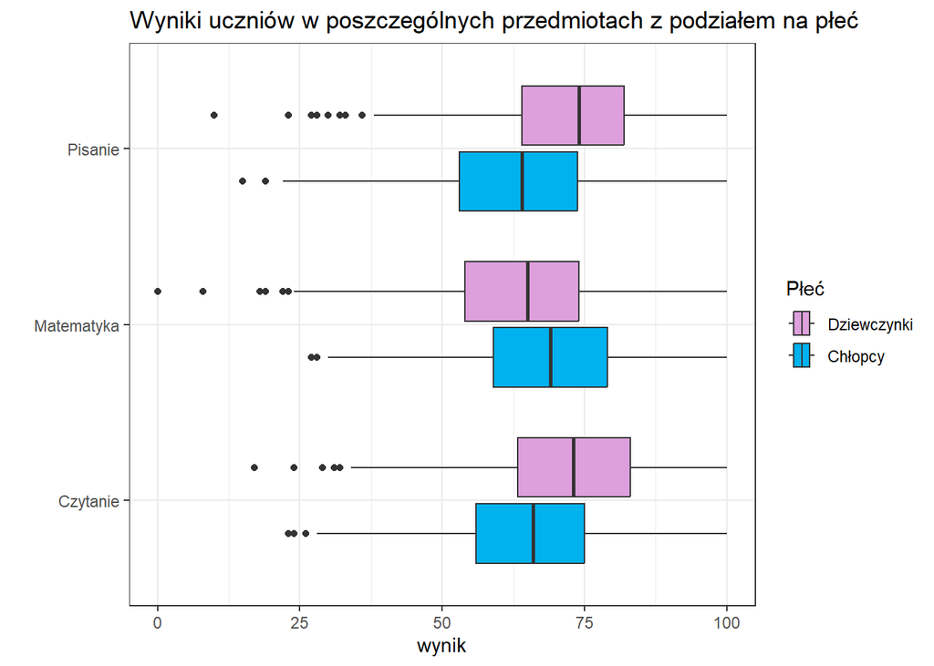

```r
# Tu umieść kod do wygenerowania odpowiedzi do zadania.
df %>% select(gender=gender,Matematyka=math.score,Czytanie=reading.score,Pisanie=writing.score) %>%
  mutate(gender = factor(gender,levels = c("male","female"),labels = c("Chłopcy","Dziewczynki"))) %>%
  pivot_longer(!gender,names_to = "Kategoria",values_to = "wynik") %>%
  ggplot(aes(x=wynik,y=Kategoria,fill=gender)) +
  geom_boxplot() + theme_bw() + ylab("") + labs(fill="Płeć") +
  scale_fill_manual(values=c("deepskyblue2","plum"),guide=guide_legend(reverse = TRUE)) +
  labs(title = "Wyniki uczniów w poszczególnych przedmiotach z podziałem na płeć")
```

**Komentarz:** Dziewczynki lepiej sobie radzą w czytaniu i pisaniu, a chłopcy mają lepsze wyniki w matematyce.

## Zadanie 3

Czy uczniowie, którzy ukończyli kurs przygotowawczy, osiągają lepsze wyniki niż pozostali?

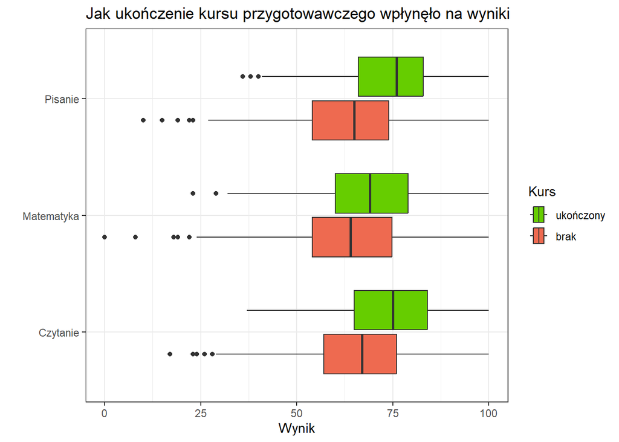

```r
# Tu umieść kod do wygenerowania odpowiedzi do zadania.
df %>% select(Kurs=test.preparation.course,Matematyka=math.score,Pisanie=writing.score,Czytanie=reading.score) %>%
  mutate(Kurs = factor(ifelse(Kurs=="none","brak","ukończony"))) %>%
  pivot_longer(!Kurs,names_to = "Przedmiot",values_to = "Wynik") %>%
  ggplot(aes(fill=Kurs,x=Wynik,y = Przedmiot)) + geom_boxplot() + theme_bw() +
  labs(y="",title = "Jak ukończenie kursu przygotowawczego wpłynęło na wyniki") +
  scale_fill_manual(values = c("coral2","chartreuse3"),guide=guide_legend(reverse = TRUE))
```

**Komentarz:** Uczniowie, ktorzy ukonczyli kurs osiagaja srednio lepsze wyniki niz pozostali.

## Zadanie 4

Jaki jest związek między poziomem wykształcenia rodziców a średnimi wynikami uczniów?

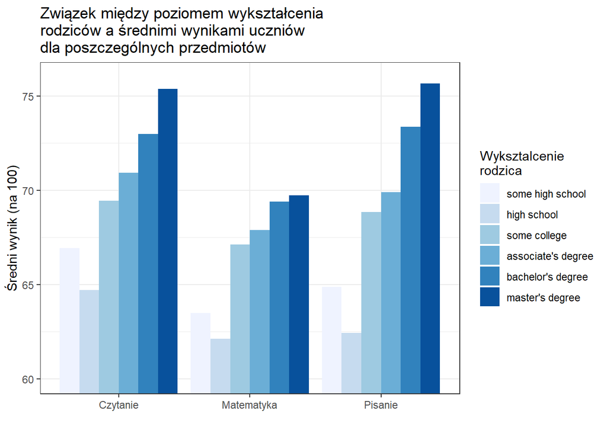

```r
# Tu umieść kod do wygenerowania odpowiedzi do zadania.



df %>%
  select(WykRodz=parental.level.of.education,
         Matematyka=math.score,
         Pisanie=writing.score,
         Czytanie=reading.score) %>%
  mutate(WykRodz = factor(WykRodz,levels = c(
  "some high school",
  "high school",
  "some college",
  "associate's degree",
  "bachelor's degree",
  "master's degree"
))) %>%
  group_by(WykRodz) %>%
  summarise_all(mean) %>%
  pivot_longer(!WykRodz) %>%
  ggplot(aes(fill=WykRodz,y=value,x=name)) +
  geom_col(position = "dodge") + coord_cartesian(ylim = c(60, 76))+
  #geom_point(size=4) +
  theme_bw() +
  labs(x="",
       y="Średni wynik (na 100)",
       fill="Wyksztalcenie\nrodzica",
       title="Związek między poziomem wykształcenia \nrodziców a średnimi wynikami uczniów \ndla poszczególnych przedmiotów") +
  scale_fill_brewer(palette="Blues")
```

```r
#df$parental.level.of.education %>% unique()
```

**Komentarz:** Widać, że im większy poziom wykształcenia rodziców, tym lepsze wyniki w nauce. Wyjątek stanowi „high school”, który z jakiegoś powodu ma niższą średnią niż „some high school”.

## Zadanie 5

Czy płeć i wykształcenie rodzica wpływa na wynik z matematyki?

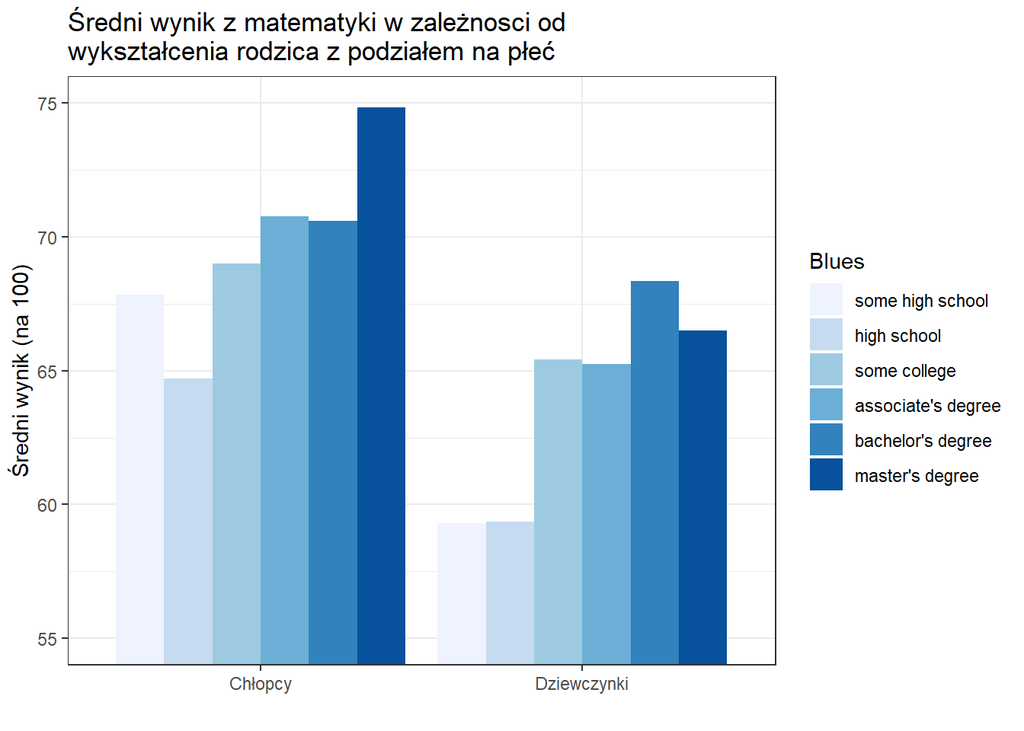

```r
# Tu umieść kod do wygenerowania odpowiedzi do zadania.
df %>%
  select(WykRodz=parental.level.of.education,gender,Matematyka=math.score) %>%
  mutate(WykRodz = factor(WykRodz,levels = c(
  "some high school",
  "high school",
  "some college",
  "associate's degree",
  "bachelor's degree",
  "master's degree"
))) %>%
  mutate(gender = factor(gender,levels = c("male","female"),labels = c("Chłopcy","Dziewczynki"))) %>%
  group_by(WykRodz,gender) %>%
  summarise(SredWynik=mean(Matematyka)) %>%
  ggplot(aes(y=SredWynik,fill=WykRodz,x=gender)) +
  #geom_point(size=4) +
  geom_col(position = "dodge")+
  coord_cartesian(ylim = c(55, 75))+
  theme_bw() +
  labs(y="Średni wynik (na 100)",x="",fill="Wyksztalcenie\nrodzica",
       title = "Średni wynik z matematyki w zależnosci od\nwykształcenia rodzica z podziałem na płeć") +
  scale_fill_brewer("Blues")
```

**Komentarz:** Im wyższe wykształcenie rodzica, tym na ogól wyższy średni wynik z matematyki. Chłopcy mają średnio lepsze wyniki od dziewczynek.

## Zadanie 6

Czy istnieje zależność między wynikami z matematyki a wynikami z czytania lub pisania?

[figure not shown]

```r
# Tu umieść kod do wygenerowania odpowiedzi do zadania.

df %>%
  select(Matematyka=math.score,Czytanie=reading.score,Pisanie=writing.score) %>%
  ggplot(aes(y=Czytanie,x=Pisanie,colour = Matematyka)) +
  geom_point() +
  labs(x="Wynik z czytania",y="Wynik z pisania",color="Wynik z\nmatematyki",
       title="Zaleznosc wyniku z matematyki\nod wynikow z czytania i pisania") +
  theme_bw() +
  scale_color_viridis_c()
```

**Komentarz:** Wynik z matematyki jest zalezny od wynikow z czytania i pisania. Im lepszy wynik z matematyki, typ lepsze wyniki z pozostalych.